# Risk Factor Analysis

## Outcome Variable

**Outcome Variable:** stunted

## Predictor Variables

**Intervention Variable:** birthlen

**Adjustment Set:**

unadjusted

## Stratifying Variables

The analysis was stratified on these variable(s):

- agecat
- studyid

The following strata were considered:

- agecat: 12 months, studyid: ki0047075b-MAL-ED
- agecat: 12 months, studyid: ki1000108-CMC-V-BCS-2002
- agecat: 12 months, studyid: ki1000108-IRC
- agecat: 12 months, studyid: ki1017093b-PROVIDE
- agecat: 12 months, studyid: ki1017093c-NIH-Crypto
- agecat: 12 months, studyid: ki1101329-Keneba
- agecat: 12 months, studyid: ki1126311-ZVITAMBO
- agecat: 12 months, studyid: ki1135781-COHORTS
- agecat: 18 months, studyid: ki0047075b-MAL-ED
- agecat: 18 months, studyid: ki1000108-CMC-V-BCS-2002
- agecat: 18 months, studyid: ki1000108-IRC
- agecat: 18 months, studyid: ki1017093b-PROVIDE
- agecat: 18 months, studyid: ki1017093c-NIH-Crypto
- agecat: 18 months, studyid: ki1101329-Keneba
- agecat: 18 months, studyid: ki1126311-ZVITAMBO
- agecat: 18 months, studyid: ki1135781-COHORTS
- agecat: 24 months, studyid: ki0047075b-MAL-ED
- agecat: 24 months, studyid: ki1000108-CMC-V-BCS-2002
- agecat: 24 months, studyid: ki1000108-IRC
- agecat: 24 months, studyid: ki1017093b-PROVIDE
- agecat: 24 months, studyid: ki1017093c-NIH-Crypto
- agecat: 24 months, studyid: ki1101329-Keneba
- agecat: 24 months, studyid: ki1126311-ZVITAMBO
- agecat: 24 months, studyid: ki1135781-COHORTS
- agecat: 3 months, studyid: ki0047075b-MAL-ED
- agecat: 3 months, studyid: ki1000108-CMC-V-BCS-2002
- agecat: 3 months, studyid: ki1000108-IRC
- agecat: 3 months, studyid: ki1017093b-PROVIDE
- agecat: 3 months, studyid: ki1017093c-NIH-Crypto
- agecat: 3 months, studyid: ki1101329-Keneba
- agecat: 3 months, studyid: ki1126311-ZVITAMBO
- agecat: 3 months, studyid: ki1135781-COHORTS
- agecat: 6 months, studyid: ki0047075b-MAL-ED
- agecat: 6 months, studyid: ki1000108-CMC-V-BCS-2002
- agecat: 6 months, studyid: ki1000108-IRC
- agecat: 6 months, studyid: ki1017093b-PROVIDE
- agecat: 6 months, studyid: ki1017093c-NIH-Crypto
- agecat: 6 months, studyid: ki1101329-Keneba
- agecat: 6 months, studyid: ki1126311-ZVITAMBO
- agecat: 6 months, studyid: ki1135781-COHORTS
- agecat: 9 months, studyid: ki0047075b-MAL-ED
- agecat: 9 months, studyid: ki1000108-CMC-V-BCS-2002
- agecat: 9 months, studyid: ki1000108-IRC
- agecat: 9 months, studyid: ki1017093b-PROVIDE
- agecat: 9 months, studyid: ki1017093c-NIH-Crypto
- agecat: 9 months, studyid: ki1101329-Keneba
- agecat: 9 months, studyid: ki1126311-ZVITAMBO
- agecat: 9 months, studyid: ki1135781-COHORTS
- agecat: Birth, studyid: ki0047075b-MAL-ED
- agecat: Birth, studyid: ki1000108-CMC-V-BCS-2002
- agecat: Birth, studyid: ki1000108-IRC
- agecat: Birth, studyid: ki1017093c-NIH-Crypto
- agecat: Birth, studyid: ki1101329-Keneba
- agecat: Birth, studyid: ki1126311-ZVITAMBO
- agecat: Birth, studyid: ki1135781-COHORTS

### Dropped Strata

Some strata were dropped due to rare outcomes:

- agecat: Birth, studyid: ki0047075b-MAL-ED
- agecat: Birth, studyid: ki1000108-CMC-V-BCS-2002
- agecat: Birth, studyid: ki1000108-IRC
- agecat: Birth, studyid: ki1017093c-NIH-Crypto
- agecat: Birth, studyid: ki1101329-Keneba
- agecat: Birth, studyid: ki1126311-ZVITAMBO
- agecat: Birth, studyid: ki1135781-COHORTS
- agecat: 3 months, studyid: ki0047075b-MAL-ED
- agecat: 3 months, studyid: ki1000108-CMC-V-BCS-2002
- agecat: 3 months, studyid: ki1017093b-PROVIDE
- agecat: 3 months, studyid: ki1017093c-NIH-Crypto
- agecat: 6 months, studyid: ki0047075b-MAL-ED
- agecat: 6 months, studyid: ki1000108-CMC-V-BCS-2002
- agecat: 6 months, studyid: ki1017093b-PROVIDE
- agecat: 6 months, studyid: ki1017093c-NIH-Crypto
- agecat: 9 months, studyid: ki0047075b-MAL-ED
- agecat: 9 months, studyid: ki1000108-CMC-V-BCS-2002
- agecat: 9 months, studyid: ki1017093b-PROVIDE
- agecat: 9 months, studyid: ki1017093c-NIH-Crypto
- agecat: 12 months, studyid: ki0047075b-MAL-ED
- agecat: 12 months, studyid: ki1000108-CMC-V-BCS-2002
- agecat: 12 months, studyid: ki1017093b-PROVIDE
- agecat: 12 months, studyid: ki1017093c-NIH-Crypto
- agecat: 18 months, studyid: ki0047075b-MAL-ED
- agecat: 18 months, studyid: ki1000108-CMC-V-BCS-2002
- agecat: 18 months, studyid: ki1017093b-PROVIDE
- agecat: 18 months, studyid: ki1017093c-NIH-Crypto
- agecat: 24 months, studyid: ki0047075b-MAL-ED
- agecat: 24 months, studyid: ki1000108-CMC-V-BCS-2002
- agecat: 24 months, studyid: ki1017093b-PROVIDE
- agecat: 24 months, studyid: ki1017093c-NIH-Crypto
- agecat: 24 months, studyid: ki1126311-ZVITAMBO

## Methods Detail

We’re interested in the causal parameters $E[Y_a]$ for all values of $a \in \mathcal{A}$. These parameters represent the mean outcome if, possibly contrary to fact, we intervened to set all units to have $A=a$. Under the randomization and positivity assumptions, these are identified by the statistical parameters $\psi_a=E_W[E_{Y|A,W}(Y|A=a,W)]$. In addition, we’re interested in the mean of $Y$, $E[Y]$ under no intervention (the observed mean). We will estimate these parameters by using SuperLearner to fit the relevant likelihood factors – $E_{Y|A,W}(Y|A=a,W)$ and $p(A=a|W)$, and then updating our likelihood fit using a joint TMLE.

For unadjusted analyses ($W=\{\}$), initial likelihoods were estimated using Lrnr_glm to estimate the simple $E(Y|A)$ and Lrnr_mean to estimate $p(A)$. For adjusted analyses, a small library containing Lrnr_glmnet, Lrnr_xgboost, and Lrnr_mean was used.

Having estimated these parameters, we will then use the delta method to estimate relative risks and attributable risks relative to a prespecified baseline level of $A$.

# Results Detail

## Results Plots

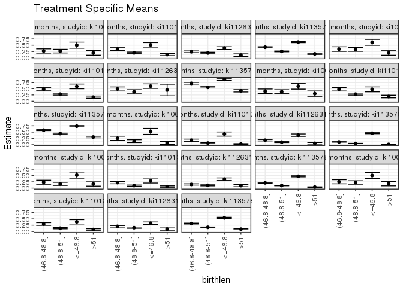

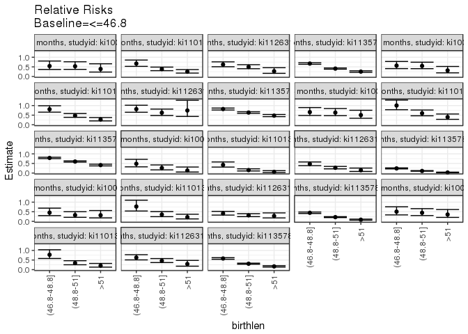

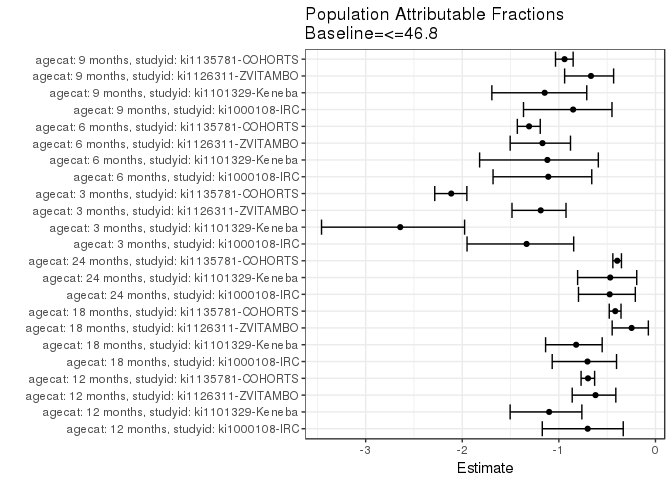

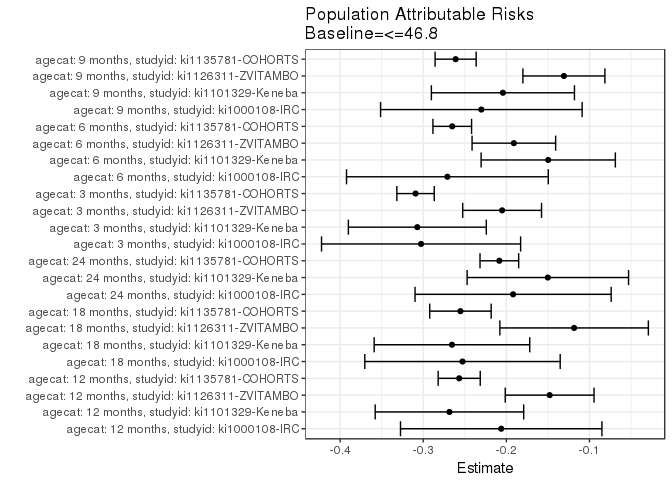

## Data Summary

| agecat | studyid | A | n | nA | nAY0 | nAY1 |
| --- | --- | --- | --- | --- | --- | --- |
| Birth | ki0047075b-MAL-ED | <=46.8 | 54 | 20 | 11 | 9 |
| Birth | ki0047075b-MAL-ED | (46.8-48.8] | 54 | 23 | 23 | 0 |
| Birth | ki0047075b-MAL-ED | (48.8-51] | 54 | 11 | 11 | 0 |
| Birth | ki0047075b-MAL-ED | >51 | 54 | 0 | 0 | 0 |
| Birth | ki1000108-CMC-V-BCS-2002 | <=46.8 | 89 | 22 | 6 | 16 |
| Birth | ki1000108-CMC-V-BCS-2002 | (46.8-48.8] | 89 | 32 | 32 | 0 |
| Birth | ki1000108-CMC-V-BCS-2002 | (48.8-51] | 89 | 34 | 34 | 0 |
| Birth | ki1000108-CMC-V-BCS-2002 | >51 | 89 | 1 | 1 | 0 |
| Birth | ki1000108-IRC | <=46.8 | 388 | 65 | 20 | 45 |
| Birth | ki1000108-IRC | (46.8-48.8] | 388 | 107 | 107 | 0 |
| Birth | ki1000108-IRC | (48.8-51] | 388 | 143 | 143 | 0 |
| Birth | ki1000108-IRC | >51 | 388 | 73 | 73 | 0 |
| Birth | ki1017093b-PROVIDE | <=46.8 | 0 | 0 | 0 | 0 |
| Birth | ki1017093b-PROVIDE | (46.8-48.8] | 0 | 0 | 0 | 0 |
| Birth | ki1017093b-PROVIDE | (48.8-51] | 0 | 0 | 0 | 0 |
| Birth | ki1017093b-PROVIDE | >51 | 0 | 0 | 0 | 0 |
| Birth | ki1017093c-NIH-Crypto | <=46.8 | 27 | 11 | 6 | 5 |
| Birth | ki1017093c-NIH-Crypto | (46.8-48.8] | 27 | 10 | 10 | 0 |
| Birth | ki1017093c-NIH-Crypto | (48.8-51] | 27 | 6 | 6 | 0 |
| Birth | ki1017093c-NIH-Crypto | >51 | 27 | 0 | 0 | 0 |
| Birth | ki1101329-Keneba | <=46.8 | 1541 | 143 | 61 | 82 |
| Birth | ki1101329-Keneba | (46.8-48.8] | 1541 | 337 | 337 | 0 |
| Birth | ki1101329-Keneba | (48.8-51] | 1541 | 730 | 730 | 0 |
| Birth | ki1101329-Keneba | >51 | 1541 | 331 | 331 | 0 |
| Birth | ki1126311-ZVITAMBO | <=46.8 | 3449 | 613 | 253 | 360 |
| Birth | ki1126311-ZVITAMBO | (46.8-48.8] | 3449 | 1095 | 1095 | 0 |
| Birth | ki1126311-ZVITAMBO | (48.8-51] | 3449 | 1410 | 1410 | 0 |
| Birth | ki1126311-ZVITAMBO | >51 | 3449 | 331 | 331 | 0 |
| Birth | ki1135781-COHORTS | <=46.8 | 10097 | 2015 | 1017 | 998 |
| Birth | ki1135781-COHORTS | (46.8-48.8] | 10097 | 3341 | 3341 | 0 |

[output cut: 194 more lines]

## Results Table

### Parameter: TSM

| agecat | studyid | intervention_level | baseline_level | estimate | ci_lower | ci_upper |
| --- | --- | --- | --- | --- | --- | --- |
| 3 months | ki1000108-IRC | <=46.8 | NA | 0.5294118 | 0.4106241 | 0.6481994 |
| 3 months | ki1000108-IRC | (46.8-48.8] | NA | 0.2547170 | 0.1716659 | 0.3377680 |
| 3 months | ki1000108-IRC | (48.8-51] | NA | 0.1408451 | 0.0835561 | 0.1981340 |
| 3 months | ki1000108-IRC | >51 | NA | 0.0694444 | 0.0106506 | 0.1282383 |
| 3 months | ki1101329-Keneba | <=46.8 | NA | 0.4233577 | 0.3405926 | 0.5061227 |
| 3 months | ki1101329-Keneba | (46.8-48.8] | NA | 0.1794872 | 0.1368899 | 0.2220845 |
| 3 months | ki1101329-Keneba | (48.8-51] | NA | 0.0654762 | 0.0467671 | 0.0841853 |
| 3 months | ki1101329-Keneba | >51 | NA | 0.0260586 | 0.0082318 | 0.0438854 |
| 3 months | ki1126311-ZVITAMBO | <=46.8 | NA | 0.3777778 | 0.3305488 | 0.4250067 |
| 3 months | ki1126311-ZVITAMBO | (46.8-48.8] | NA | 0.1786704 | 0.1507217 | 0.2066190 |
| 3 months | ki1126311-ZVITAMBO | (48.8-51] | NA | 0.1038674 | 0.0839860 | 0.1237488 |
| 3 months | ki1126311-ZVITAMBO | >51 | NA | 0.0558140 | 0.0251219 | 0.0865060 |
| 3 months | ki1135781-COHORTS | <=46.8 | NA | 0.4554919 | 0.4332204 | 0.4777634 |
| 3 months | ki1135781-COHORTS | (46.8-48.8] | NA | 0.1102484 | 0.0994300 | 0.1210669 |
| 3 months | ki1135781-COHORTS | (48.8-51] | NA | 0.0499569 | 0.0427215 | 0.0571923 |
| 3 months | ki1135781-COHORTS | >51 | NA | 0.0130719 | 0.0062691 | 0.0198747 |
| 6 months | ki1000108-IRC | <=46.8 | NA | 0.5151515 | 0.3944242 | 0.6358788 |
| 6 months | ki1000108-IRC | (46.8-48.8] | NA | 0.2336449 | 0.1533647 | 0.3139250 |
| 6 months | ki1000108-IRC | (48.8-51] | NA | 0.1678322 | 0.1065009 | 0.2291635 |
| 6 months | ki1000108-IRC | >51 | NA | 0.1643836 | 0.0792544 | 0.2495127 |
| 6 months | ki1101329-Keneba | <=46.8 | NA | 0.2833333 | 0.2026793 | 0.3639874 |
| 6 months | ki1101329-Keneba | (46.8-48.8] | NA | 0.2184300 | 0.1711023 | 0.2657578 |
| 6 months | ki1101329-Keneba | (48.8-51] | NA | 0.0998440 | 0.0766273 | 0.1230607 |
| 6 months | ki1101329-Keneba | >51 | NA | 0.0616438 | 0.0340478 | 0.0892399 |
| 6 months | ki1126311-ZVITAMBO | <=46.8 | NA | 0.3542857 | 0.3041649 | 0.4044065 |
| 6 months | ki1126311-ZVITAMBO | (46.8-48.8] | NA | 0.1460507 | 0.1193230 | 0.1727784 |
| 6 months | ki1126311-ZVITAMBO | (48.8-51] | NA | 0.1108404 | 0.0893610 | 0.1323198 |
| 6 months | ki1126311-ZVITAMBO | >51 | NA | 0.0994764 | 0.0570198 | 0.1419331 |
| 6 months | ki1135781-COHORTS | <=46.8 | NA | 0.4677419 | 0.4446776 | 0.4908063 |
| 6 months | ki1135781-COHORTS | (46.8-48.8] | NA | 0.2085106 | 0.1941043 | 0.2229170 |

[output cut: 62 more lines]

### Parameter: E(Y)

| agecat | studyid | intervention_level | baseline_level | estimate | ci_lower | ci_upper |
| --- | --- | --- | --- | --- | --- | --- |
| 3 months | ki1000108-IRC | NA | NA | 0.2268041 | 0.2115113 | 0.2420969 |
| 3 months | ki1101329-Keneba | NA | NA | 0.1162465 | 0.1103572 | 0.1221358 |
| 3 months | ki1126311-ZVITAMBO | NA | NA | 0.1726747 | 0.1683753 | 0.1769740 |
| 3 months | ki1135781-COHORTS | NA | NA | 0.1462610 | 0.1431343 | 0.1493876 |
| 6 months | ki1000108-IRC | NA | NA | 0.2442159 | 0.2316984 | 0.2567335 |
| 6 months | ki1101329-Keneba | NA | NA | 0.1337296 | 0.1298642 | 0.1375949 |
| 6 months | ki1126311-ZVITAMBO | NA | NA | 0.1633055 | 0.1594478 | 0.1671631 |
| 6 months | ki1135781-COHORTS | NA | NA | 0.2026408 | 0.1997222 | 0.2055594 |
| 9 months | ki1000108-IRC | NA | NA | 0.2699229 | 0.2592840 | 0.2805617 |
| 9 months | ki1101329-Keneba | NA | NA | 0.1779789 | 0.1725908 | 0.1833670 |
| 9 months | ki1126311-ZVITAMBO | NA | NA | 0.1958763 | 0.1928027 | 0.1989499 |
| 9 months | ki1135781-COHORTS | NA | NA | 0.2773292 | 0.2741422 | 0.2805161 |
| 12 months | ki1000108-IRC | NA | NA | 0.2938144 | 0.2841048 | 0.3035240 |
| 12 months | ki1101329-Keneba | NA | NA | 0.2439222 | 0.2375433 | 0.2503011 |
| 12 months | ki1126311-ZVITAMBO | NA | NA | 0.2383790 | 0.2345403 | 0.2422177 |
| 12 months | ki1135781-COHORTS | NA | NA | 0.3675562 | 0.3641405 | 0.3709719 |
| 18 months | ki1000108-IRC | NA | NA | 0.3591731 | 0.3463218 | 0.3720244 |
| 18 months | ki1101329-Keneba | NA | NA | 0.3233083 | 0.3157259 | 0.3308907 |
| 18 months | ki1126311-ZVITAMBO | NA | NA | 0.4798100 | 0.4715165 | 0.4881034 |
| 18 months | ki1135781-COHORTS | NA | NA | 0.6132556 | 0.6081762 | 0.6183351 |
| 24 months | ki1000108-IRC | NA | NA | 0.4051282 | 0.3958796 | 0.4143768 |
| 24 months | ki1101329-Keneba | NA | NA | 0.3204887 | 0.3140537 | 0.3269237 |
| 24 months | ki1135781-COHORTS | NA | NA | 0.5264568 | 0.5234678 | 0.5294458 |

### Parameter: RR

| agecat | studyid | intervention_level | baseline_level | estimate | ci_lower | ci_upper |
| --- | --- | --- | --- | --- | --- | --- |
| 3 months | ki1000108-IRC | (46.8-48.8] | <=46.8 | 0.4811321 | 0.3238710 | 0.7147540 |
| 3 months | ki1000108-IRC | (48.8-51] | <=46.8 | 0.2660407 | 0.1671874 | 0.4233432 |
| 3 months | ki1000108-IRC | >51 | <=46.8 | 0.1311728 | 0.0546340 | 0.3149380 |
| 3 months | ki1101329-Keneba | (46.8-48.8] | <=46.8 | 0.4239611 | 0.3117378 | 0.5765840 |
| 3 months | ki1101329-Keneba | (48.8-51] | <=46.8 | 0.1546593 | 0.1093997 | 0.2186431 |
| 3 months | ki1101329-Keneba | >51 | <=46.8 | 0.0615523 | 0.0302168 | 0.1253833 |
| 3 months | ki1126311-ZVITAMBO | (46.8-48.8] | <=46.8 | 0.4729510 | 0.3871242 | 0.5778058 |
| 3 months | ki1126311-ZVITAMBO | (48.8-51] | <=46.8 | 0.2749431 | 0.2187530 | 0.3455666 |
| 3 months | ki1126311-ZVITAMBO | >51 | <=46.8 | 0.1477428 | 0.0840609 | 0.2596681 |
| 3 months | ki1135781-COHORTS | (46.8-48.8] | <=46.8 | 0.2420426 | 0.2169092 | 0.2700882 |
| 3 months | ki1135781-COHORTS | (48.8-51] | <=46.8 | 0.1096769 | 0.0941298 | 0.1277918 |
| 3 months | ki1135781-COHORTS | >51 | <=46.8 | 0.0286985 | 0.0170157 | 0.0484024 |
| 6 months | ki1000108-IRC | (46.8-48.8] | <=46.8 | 0.4535459 | 0.2992220 | 0.6874624 |
| 6 months | ki1000108-IRC | (48.8-51] | <=46.8 | 0.3257919 | 0.2110587 | 0.5028947 |
| 6 months | ki1000108-IRC | >51 | <=46.8 | 0.3190975 | 0.1807418 | 0.5633629 |
| 6 months | ki1101329-Keneba | (46.8-48.8] | <=46.8 | 0.7709295 | 0.5390754 | 1.1025032 |
| 6 months | ki1101329-Keneba | (48.8-51] | <=46.8 | 0.3523906 | 0.2440023 | 0.5089260 |
| 6 months | ki1101329-Keneba | >51 | <=46.8 | 0.2175665 | 0.1279956 | 0.3698189 |
| 6 months | ki1126311-ZVITAMBO | (46.8-48.8] | <=46.8 | 0.4122398 | 0.3271099 | 0.5195246 |
| 6 months | ki1126311-ZVITAMBO | (48.8-51] | <=46.8 | 0.3128561 | 0.2461182 | 0.3976907 |
| 6 months | ki1126311-ZVITAMBO | >51 | <=46.8 | 0.2807803 | 0.1790985 | 0.4401911 |
| 6 months | ki1135781-COHORTS | (46.8-48.8] | <=46.8 | 0.4457814 | 0.4095036 | 0.4852730 |
| 6 months | ki1135781-COHORTS | (48.8-51] | <=46.8 | 0.2191752 | 0.1958749 | 0.2452472 |
| 6 months | ki1135781-COHORTS | >51 | <=46.8 | 0.0864450 | 0.0637916 | 0.1171429 |
| 9 months | ki1000108-IRC | (46.8-48.8] | <=46.8 | 0.5046729 | 0.3361996 | 0.7575700 |
| 9 months | ki1000108-IRC | (48.8-51] | <=46.8 | 0.4475524 | 0.3031443 | 0.6607520 |
| 9 months | ki1000108-IRC | >51 | <=46.8 | 0.3561644 | 0.2056098 | 0.6169604 |
| 9 months | ki1101329-Keneba | (46.8-48.8] | <=46.8 | 0.7757599 | 0.5814497 | 1.0350051 |
| 9 months | ki1101329-Keneba | (48.8-51] | <=46.8 | 0.3436911 | 0.2542848 | 0.4645325 |
| 9 months | ki1101329-Keneba | >51 | <=46.8 | 0.2068436 | 0.1316009 | 0.3251063 |
| 9 months | ki1126311-ZVITAMBO | (46.8-48.8] | <=46.8 | 0.6284685 | 0.5073394 | 0.7785177 |
| 9 months | ki1126311-ZVITAMBO | (48.8-51] | <=46.8 | 0.4619509 | 0.3690943 | 0.5781684 |
| 9 months | ki1126311-ZVITAMBO | >51 | <=46.8 | 0.2950750 | 0.1808329 | 0.4814903 |
| 9 months | ki1135781-COHORTS | (46.8-48.8] | <=46.8 | 0.5804614 | 0.5402906 | 0.6236191 |
| 9 months | ki1135781-COHORTS | (48.8-51] | <=46.8 | 0.3078316 | 0.2807272 | 0.3375529 |
| 9 months | ki1135781-COHORTS | >51 | <=46.8 | 0.1692193 | 0.1376363 | 0.2080495 |
| 12 months | ki1000108-IRC | (46.8-48.8] | <=46.8 | 0.5420561 | 0.3655700 | 0.8037443 |
| 12 months | ki1000108-IRC | (48.8-51] | <=46.8 | 0.5314685 | 0.3691720 | 0.7651144 |
| 12 months | ki1000108-IRC | >51 | <=46.8 | 0.3888889 | 0.2291048 | 0.6601109 |
| 12 months | ki1101329-Keneba | (46.8-48.8] | <=46.8 | 0.6706315 | 0.5264557 | 0.8542914 |
| 12 months | ki1101329-Keneba | (48.8-51] | <=46.8 | 0.3837069 | 0.3023001 | 0.4870359 |
| 12 months | ki1101329-Keneba | >51 | <=46.8 | 0.2513441 | 0.1755646 | 0.3598325 |
| 12 months | ki1126311-ZVITAMBO | (46.8-48.8] | <=46.8 | 0.6207386 | 0.5073724 | 0.7594349 |
| 12 months | ki1126311-ZVITAMBO | (48.8-51] | <=46.8 | 0.4973769 | 0.4037690 | 0.6126864 |
| 12 months | ki1126311-ZVITAMBO | >51 | <=46.8 | 0.2724958 | 0.1629031 | 0.4558166 |
| 12 months | ki1135781-COHORTS | (46.8-48.8] | <=46.8 | 0.6721285 | 0.6323378 | 0.7144231 |
| 12 months | ki1135781-COHORTS | (48.8-51] | <=46.8 | 0.4085724 | 0.3789121 | 0.4405545 |
| 12 months | ki1135781-COHORTS | >51 | <=46.8 | 0.2520674 | 0.2154941 | 0.2948478 |
| 18 months | ki1000108-IRC | (46.8-48.8] | <=46.8 | 0.5650786 | 0.4089618 | 0.7807914 |
| 18 months | ki1000108-IRC | (48.8-51] | <=46.8 | 0.5486063 | 0.4058180 | 0.7416351 |
| 18 months | ki1000108-IRC | >51 | <=46.8 | 0.3133979 | 0.1884353 | 0.5212306 |
| 18 months | ki1101329-Keneba | (46.8-48.8] | <=46.8 | 0.8062504 | 0.6574138 | 0.9887831 |
| 18 months | ki1101329-Keneba | (48.8-51] | <=46.8 | 0.4762745 | 0.3875528 | 0.5853070 |
| 18 months | ki1101329-Keneba | >51 | <=46.8 | 0.2745554 | 0.2001051 | 0.3767055 |
| 18 months | ki1126311-ZVITAMBO | (46.8-48.8] | <=46.8 | 0.8134286 | 0.6516478 | 1.0153737 |
| 18 months | ki1126311-ZVITAMBO | (48.8-51] | <=46.8 | 0.6267857 | 0.4817291 | 0.8155213 |
| 18 months | ki1126311-ZVITAMBO | >51 | <=46.8 | 0.7428571 | 0.4337425 | 1.2722680 |
| 18 months | ki1135781-COHORTS | (46.8-48.8] | <=46.8 | 0.8170821 | 0.7685646 | 0.8686624 |
| 18 months | ki1135781-COHORTS | (48.8-51] | <=46.8 | 0.6343902 | 0.5935952 | 0.6779888 |
| 18 months | ki1135781-COHORTS | >51 | <=46.8 | 0.4759864 | 0.4222098 | 0.5366124 |
| 24 months | ki1000108-IRC | (46.8-48.8] | <=46.8 | 0.6574766 | 0.4834713 | 0.8941080 |
| 24 months | ki1000108-IRC | (48.8-51] | <=46.8 | 0.6325175 | 0.4740355 | 0.8439840 |
| 24 months | ki1000108-IRC | >51 | <=46.8 | 0.5047945 | 0.3379083 | 0.7541025 |
| 24 months | ki1101329-Keneba | (46.8-48.8] | <=46.8 | 1.0016520 | 0.7818044 | 1.2833219 |
| 24 months | ki1101329-Keneba | (48.8-51] | <=46.8 | 0.5988258 | 0.4672223 | 0.7674984 |
| 24 months | ki1101329-Keneba | >51 | <=46.8 | 0.3984375 | 0.2831003 | 0.5607640 |
| 24 months | ki1135781-COHORTS | (46.8-48.8] | <=46.8 | 0.7861904 | 0.7509129 | 0.8231251 |
| 24 months | ki1135781-COHORTS | (48.8-51] | <=46.8 | 0.5991859 | 0.5683639 | 0.6316792 |
| 24 months | ki1135781-COHORTS | >51 | <=46.8 | 0.4146240 | 0.3728125 | 0.4611247 |

### Parameter: PAR

| agecat | studyid | intervention_level | baseline_level | estimate | ci_lower | ci_upper |
| --- | --- | --- | --- | --- | --- | --- |
| 3 months | ki1000108-IRC | <=46.8 | NA | -0.3026076 | -0.4223757 | -0.1828396 |
| 3 months | ki1101329-Keneba | <=46.8 | NA | -0.3071112 | -0.3900855 | -0.2241369 |
| 3 months | ki1126311-ZVITAMBO | <=46.8 | NA | -0.2051031 | -0.2525273 | -0.1576789 |
| 3 months | ki1135781-COHORTS | <=46.8 | NA | -0.3092310 | -0.3317209 | -0.2867411 |
| 6 months | ki1000108-IRC | <=46.8 | NA | -0.2709356 | -0.3923101 | -0.1495611 |
| 6 months | ki1101329-Keneba | <=46.8 | NA | -0.1496038 | -0.2303504 | -0.0688571 |
| 6 months | ki1126311-ZVITAMBO | <=46.8 | NA | -0.1909803 | -0.2412493 | -0.1407112 |
| 6 months | ki1135781-COHORTS | <=46.8 | NA | -0.2651012 | -0.2883494 | -0.2418529 |
| 9 months | ki1000108-IRC | <=46.8 | NA | -0.2300771 | -0.3513276 | -0.1088267 |
| 9 months | ki1101329-Keneba | <=46.8 | NA | -0.2041349 | -0.2902071 | -0.1180628 |
| 9 months | ki1126311-ZVITAMBO | <=46.8 | NA | -0.1307713 | -0.1800834 | -0.0814592 |
| 9 months | ki1135781-COHORTS | <=46.8 | NA | -0.2610356 | -0.2857475 | -0.2363238 |
| 12 months | ki1000108-IRC | <=46.8 | NA | -0.2061856 | -0.3273584 | -0.0850127 |
| 12 months | ki1101329-Keneba | <=46.8 | NA | -0.2684745 | -0.3578005 | -0.1791484 |
| 12 months | ki1126311-ZVITAMBO | <=46.8 | NA | -0.1479138 | -0.2013319 | -0.0944957 |
| 12 months | ki1135781-COHORTS | <=46.8 | NA | -0.2567455 | -0.2820624 | -0.2314285 |
| 18 months | ki1000108-IRC | <=46.8 | NA | -0.2527672 | -0.3703077 | -0.1352266 |
| 18 months | ki1101329-Keneba | <=46.8 | NA | -0.2654768 | -0.3590563 | -0.1718972 |
| 18 months | ki1126311-ZVITAMBO | <=46.8 | NA | -0.1184806 | -0.2078037 | -0.0291575 |
| 18 months | ki1135781-COHORTS | <=46.8 | NA | -0.2552459 | -0.2922316 | -0.2182602 |
| 24 months | ki1000108-IRC | <=46.8 | NA | -0.1918867 | -0.3098493 | -0.0739242 |
| 24 months | ki1101329-Keneba | <=46.8 | NA | -0.1500995 | -0.2472231 | -0.0529759 |
| 24 months | ki1135781-COHORTS | <=46.8 | NA | -0.2084401 | -0.2316979 | -0.1851824 |

### Parameter: PAF

| agecat | studyid | intervention_level | baseline_level | estimate | ci_lower | ci_upper |
| --- | --- | --- | --- | --- | --- | --- |
| 3 months | ki1000108-IRC | <=46.8 | NA | -1.3342246 | -1.9504826 | -0.8466824 |
| 3 months | ki1101329-Keneba | <=46.8 | NA | -2.6418961 | -3.4569244 | -1.9759102 |
| 3 months | ki1126311-ZVITAMBO | <=46.8 | NA | -1.1878007 | -1.4852415 | -0.9259584 |
| 3 months | ki1135781-COHORTS | <=46.8 | NA | -2.1142413 | -2.2849448 | -1.9524085 |
| 6 months | ki1000108-IRC | <=46.8 | NA | -1.1094099 | -1.6812979 | -0.6594986 |
| 6 months | ki1101329-Keneba | <=46.8 | NA | -1.1187037 | -1.8205433 | -0.5915038 |
| 6 months | ki1126311-ZVITAMBO | <=46.8 | NA | -1.1694664 | -1.5040512 | -0.8795880 |
| 6 months | ki1135781-COHORTS | <=46.8 | NA | -1.3082321 | -1.4299053 | -1.1926515 |
| 9 months | ki1000108-IRC | <=46.8 | NA | -0.8523810 | -1.3660733 | -0.4502151 |
| 9 months | ki1101329-Keneba | <=46.8 | NA | -1.1469616 | -1.6936406 | -0.7112319 |
| 9 months | ki1126311-ZVITAMBO | <=46.8 | NA | -0.6676218 | -0.9403805 | -0.4332046 |
| 9 months | ki1135781-COHORTS | <=46.8 | NA | -0.9412484 | -1.0345564 | -0.8522196 |
| 12 months | ki1000108-IRC | <=46.8 | NA | -0.7017544 | -1.1716257 | -0.3335484 |
| 12 months | ki1101329-Keneba | <=46.8 | NA | -1.1006562 | -1.5045024 | -0.7619294 |
| 12 months | ki1126311-ZVITAMBO | <=46.8 | NA | -0.6204984 | -0.8618992 | -0.4103960 |
| 12 months | ki1135781-COHORTS | <=46.8 | NA | -0.6985203 | -0.7700357 | -0.6298944 |
| 18 months | ki1000108-IRC | <=46.8 | NA | -0.7037474 | -1.0690321 | -0.4029533 |
| 18 months | ki1101329-Keneba | <=46.8 | NA | -0.8211258 | -1.1374116 | -0.5516428 |
| 18 months | ki1126311-ZVITAMBO | <=46.8 | NA | -0.2469324 | -0.4482273 | -0.0736163 |
| 18 months | ki1135781-COHORTS | <=46.8 | NA | -0.4162145 | -0.4784217 | -0.3566248 |
| 24 months | ki1000108-IRC | <=46.8 | NA | -0.4736444 | -0.7968517 | -0.2085738 |
| 24 months | ki1101329-Keneba | <=46.8 | NA | -0.4683457 | -0.8058784 | -0.1939005 |
| 24 months | ki1135781-COHORTS | <=46.8 | NA | -0.3959302 | -0.4411704 | -0.3521101 |